# Perceptual Phenomenon

by Rica Enriquez

``In a Stroop task, participants are presented with a list of words, with each word displayed in a color of ink. The participant’s task is to say out loud the color of the ink in which the word is printed. The task has two conditions: a congruent words condition, and an incongruent words condition. In the congruent words condition, the words being displayed are color words whose names match the colors in which they are printed: for example RED, BLUE. In the incongruent words condition, the words displayed are color words whose names do not match the colors in which they are printed: for example PURPLE, ORANGE." For each case, the time it takes to name the ink colors in equally-sized lists is measured and recorded.

For these tests, the independent variable is the words condition and the dependent variable is the time it takes to name the ink colors, $\mu$. With the data given, I will examine if the two different samples have different means because they come from different populations or if they have different means because of chance. The null hypothesis states that the population mean completion time does not increase significantly with the use of an incongruent words condition. The alternative hypothesis states that an incongruent words conditions significantly increases the population mean completion time. The following hypotheses are tested:

Null Hypothesis, $H_0: \mu_{congruent} - \mu_{incongruent} \geq 0$,

and

Alternative Hypothesis, $H_a: \mu_{congruent} - \mu_{incongruent} < 0$.

I plan to perform a one-tailed dependent t-test with $\alpha$ = 0.05. The dependent t-test will help determine whether the increase in the mean completion time of the incongruent samples is due to a difference in populations. A dependent t-test is applicable when there are less than 30 samples, the population’s standard deviation is unknown, and the population distribution is unknown (applicable when it is not normal).

Before testing, the hypotheses, it is a good idea to examine some descriptive statistics and plots. The mean time of completion for the congruent list sample, $\overline{x}_{congruent}$, is 14.051 s. The mean time of completion for the incongruent list sample, $\overline{x}_{incongruent}$, is 22.0159 s. The mean difference between the two samples, $\overline{x}_D = \overline{x}_{congruent} - \overline{x}_{incongruent}$, is -7.965 s with a standard error, $S$, equal to 0.993 s. The two histograms below also show that the distribution of completion times for the incongruent words sample is centered at a longer time period than it is for the congruent words sample. Additionally, the histograms justify the use of a t-statistics over z-statistics since the histograms do not appear perfectly normal, but are not highly skewed.

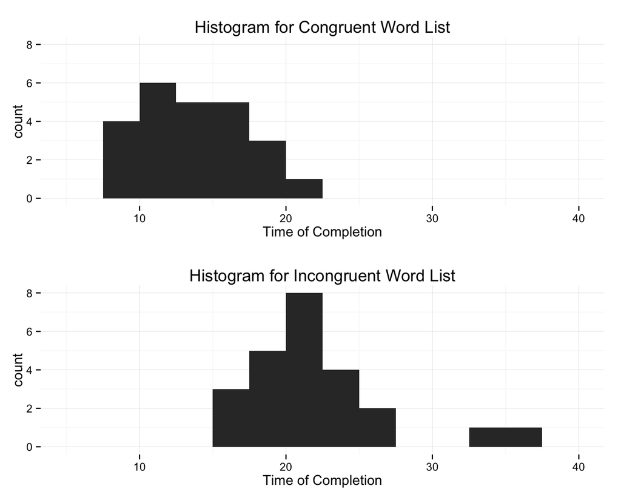

The t-statistic for the two samples is -8.021. With $\alpha = 0.05$ and 23 degrees of freedom, the t-critical value for a one-tailed test is -1.714 The p-value calculated from the t-statistic and 23 degrees of freedom gives a p-value that is less than 0.0001.

Because the p-value is less than 0.05 and the |t-statistic| is greater than the |t-critical| value, I reject the null hypothesis. Therefore, difference in the completion time due to word condition is likely because the the samples come from two different populations and not by chance. The data shows that the use of the incongruent word condition leads to an average longer time of completion. Given that the effect of incongruent words is named (Stroop Effect), the results agree with my expectations.

There are a couple theories as to why the Stroop Effect occurs. They include:

1. Processing speed: There’s an assumption that word processing is faster than color processing. As a result, the incongruent completion time would be longer.
2. Selective attention: There’s an assumption that color recognition as opposed to reading a word, requires more attention and so it takes a little longer. As a result, the incongruent completion time would be longer.
3. Automaticity: There’s an assumption that there is hesitancy to respond since color recognition is not an automatic process, whereas, the brain automatically understands the meaning of words as a result of habitual reading.

A similar test is the Numerical Stroop Test which shows the relationship between the value and physical size of digits. A digit can be presented as big or small by its physical size. Comparing different digits in incongruent trials (different physical sizes) is slower than comparing different digits in congruent trials (same physical sizes) and the difference in reaction time is termed the numerical Stroop effect.

##### References

1. Udacity Statistics Class Notes
2. Minitab Support: http://support.minitab.com/en-us/minitab/17/topic-library/basic-statistics-and-graphs/hypothesis-tests/basics/what-is-a-hypothesis-test/
3. T-Score vs. Z-Score: What’s the Difference?: http://www.statisticshowto.com/when-to-use-a-t-score-vs-z-score/